# Task-3: Iris Flower Classification

Kankana Ghosh

2023-07-21

Importing all the necessary libraries required for the analysis.

```r
rm(list=ls())
library(MASS)
library(klaR)
library(clusterSim)
library(GGally)
library(ggpubr)
df=iris
class(df)
```

```
## [1] "data.frame"
```

```r
str(df)
```

```
## 'data.frame':    150 obs. of  5 variables:
##  $ Sepal.Length: num  5.1 4.9 4.7 4.6 5 5.4 4.6 5 4.4 4.9 ...
##  $ Sepal.Width : num  3.5 3 3.2 3.1 3.6 3.9 3.4 3.4 2.9 3.1 ...
##  $ Petal.Length: num  1.4 1.4 1.3 1.5 1.4 1.7 1.4 1.5 1.4 1.5 ...
##  $ Petal.Width : num  0.2 0.2 0.2 0.2 0.2 0.4 0.3 0.2 0.2 0.1 ...
##  $ Species     : Factor w/ 3 levels "setosa","versicolor",..: 1 1 1 1 1 1 1 1 1 1 ...
```

**Comments:** The dataset Iris is a dataframe in nature consisting 150 observations on 5 variables. The variable Species is categorical in nature having “Setosa”, “versicolor” and “virginica” corresponding to which there are four variables taking measurements on it’s Sepal Length, Sepal Width, Petal Length and Petal Width.

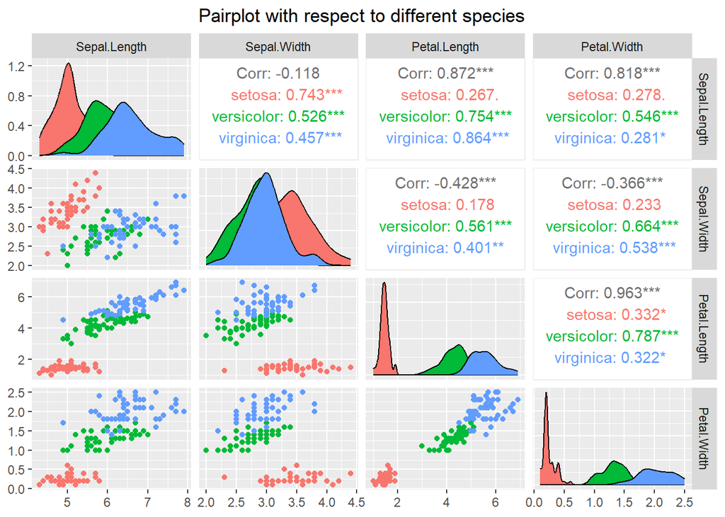

```r
ggpairs(df,columns = 1:4,ggplot2::aes(colour=Species))+ggtitle("Pairplot with respect to different species")+
  theme(plot.title = element_text(hjust=0.5))
```

**Comments:** From the pairplot we get the idea of the correlation between different measurements of the 3 species.

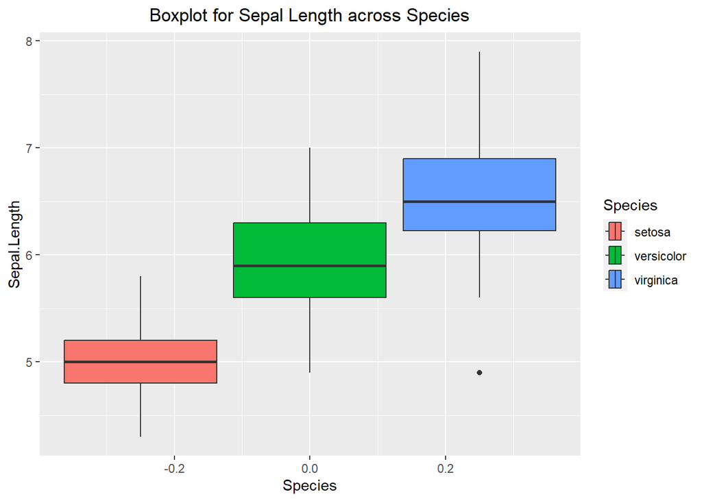

```r
ggplot(data=df,aes(x=Sepal.Length,fill=factor(Species)))+geom_boxplot()+scale_fill_discrete(name="Species")+
  coord_flip()+ylab("Species")+ggtitle("Boxplot for Sepal Length across Species")+
  theme(plot.title = element_text(hjust=0.5))
```

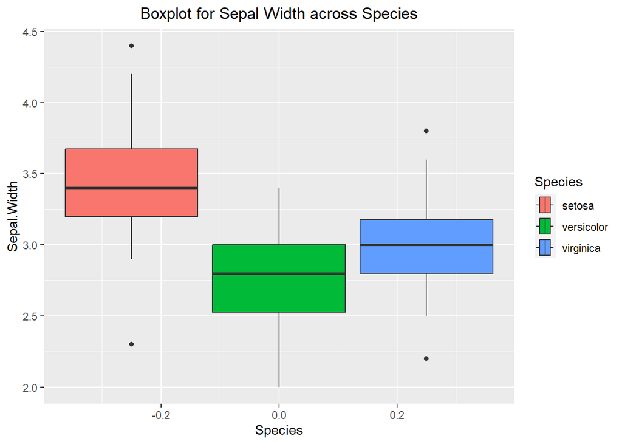

```r
ggplot(data=df,aes(x=Sepal.Width,fill=factor(Species)))+geom_boxplot()+scale_fill_discrete(name="Species")+
  coord_flip()+ylab("Species")+ggtitle("Boxplot for Sepal Width across Species")+
  theme(plot.title = element_text(hjust=0.5))
```

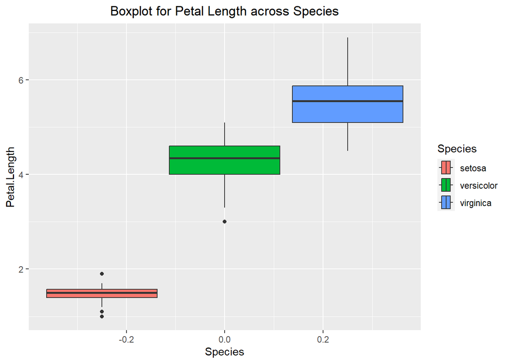

```r
ggplot(data=df,aes(x=Petal.Length,fill=factor(Species)))+geom_boxplot()+scale_fill_discrete(name="Species")+
  coord_flip()+ylab("Species")+ggtitle("Boxplot for Petal Length across Species")+
  theme(plot.title = element_text(hjust=0.5))
```

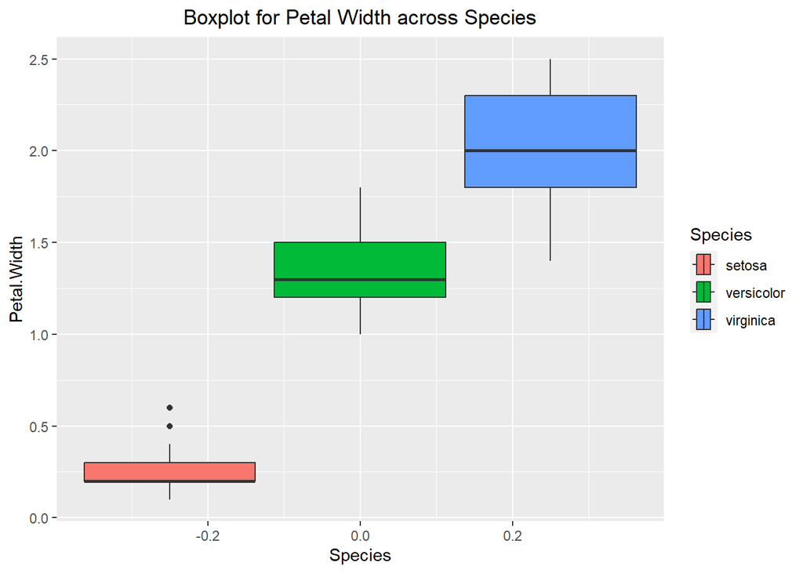

```r
ggplot(data=df,aes(x=Petal.Width,fill=factor(Species)))+geom_boxplot()+scale_fill_discrete(name="Species")+
  coord_flip()+ylab("Species")+ggtitle("Boxplot for Petal Width across Species")+
  theme(plot.title = element_text(hjust=0.5))
```

**Comments:** From the boxplot for Sepal Length across species it is clear that the Sepal Length of the specie virginica is more compared to the other two species.Virginica has outlier present in them.

From the boxplot for Sepal Width across species it is clear that the Sepal Width of the specie setosa is more compared to the other two species.Virginica and setosa has outlier present in them.

From the boxplot for Petal Length across species it is clear that the Petal Length of the specie virginica is more compared to the other two species.Versicolor and setosa has outlier present in them.

From the boxplot for Petal Width across species it is clear that the Petal Width of the specie virginica is more compared to the other two species.Setosa has outlier present in them.

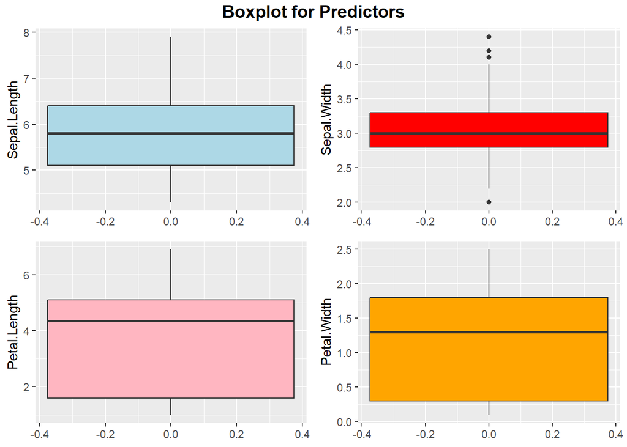

```r
a=ggplot(data=df,aes(x=Sepal.Length))+geom_boxplot(aes(Sepal.Length),fill="lightblue")+coord_flip()
b=ggplot(data=df,aes(x=Sepal.Width))+geom_boxplot(aes(Sepal.Width),fill="red")+coord_flip()
d=ggplot(data=df,aes(x=Petal.Length))+geom_boxplot(aes(Petal.Length),fill="lightpink")+coord_flip()
e=ggplot(data=df,aes(x=Petal.Width))+geom_boxplot(aes(Petal.Width),fill="orange")+coord_flip()
plot=ggarrange(a,b,d,e)
annotate_figure(plot,top=text_grob("Boxplot for Predictors",face="bold",size=14))
```

```r
apply(df[,-5], 2,mean)
```

```
## Sepal.Length  Sepal.Width Petal.Length  Petal.Width
##     5.843333     3.057333     3.758000     1.199333
```

```r
apply(df[,-5], 2,var)
```

```
## Sepal.Length  Sepal.Width Petal.Length  Petal.Width
##    0.6856935    0.1899794    3.1162779    0.5810063
```

```r
apply(df[,-5], 2,median)
```

```
## Sepal.Length  Sepal.Width Petal.Length  Petal.Width
##         5.80         3.00         4.35         1.30
```

Splitting the dataset into train and test data in the ratio of 80:20.

```r
s=sample(c(TRUE,FALSE),nrow(df),replace=TRUE,c(0.8,0.2))
train=df[s,]
test=df[!s,]
model=lda(Species~.,data=train)
model
```

```
## Call:
## lda(Species ~ ., data = train)
##
## Prior probabilities of groups:
##     setosa versicolor  virginica
##      0.336      0.320      0.344
##
## Group means:
##            Sepal.Length Sepal.Width Petal.Length Petal.Width
## setosa         5.002381    3.411905     1.435714   0.2452381
## versicolor     5.940000    2.737500     4.197500   1.2950000
## virginica      6.583721    2.990698     5.520930   2.0139535
##
## Coefficients of linear discriminants:
##                     LD1        LD2
## Sepal.Length  0.9910098 -0.4190550
## Sepal.Width   1.3844452  2.5286025
## Petal.Length -2.3815360 -0.7132331
## Petal.Width  -2.8749280  2.7994152
##
## Proportion of trace:
##    LD1    LD2
## 0.9891 0.0109
```

```r
pred=predict(model,newdata =  test)
pred
```

```
## $class
##  [1] setosa     setosa     setosa     setosa     setosa     setosa
##  [7] setosa     setosa     versicolor versicolor versicolor versicolor
## [13] versicolor virginica  versicolor virginica  versicolor versicolor
## [19] virginica  virginica  virginica  virginica  virginica  virginica
## [25] virginica
## Levels: setosa versicolor virginica
##
## $posterior
##           setosa   versicolor    virginica
## 5   1.000000e+00 3.417897e-23 4.615776e-45
## 8   1.000000e+00 9.205464e-21 4.787181e-42
## 9   1.000000e+00 6.278857e-16 7.112343e-36
## 19  1.000000e+00 3.372687e-23 7.763452e-45
## 20  1.000000e+00 6.728271e-23 4.504383e-44
```

[output cut: 48 more lines]

```r
mean(pred$class==test$Species)
```

```
## [1] 0.92
```

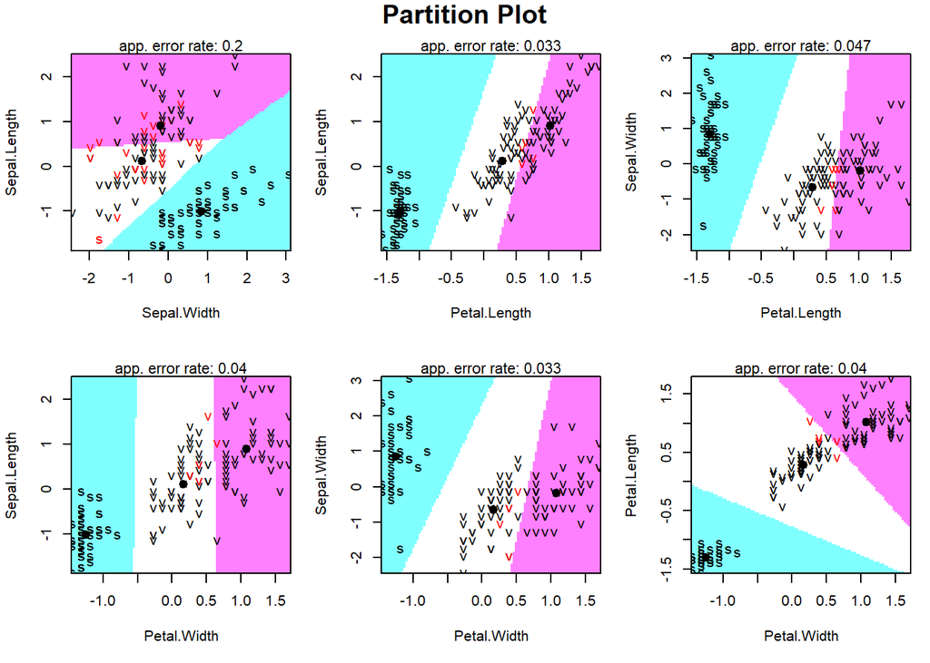

```r
df.standard=data.Normalization(df[,-5],type="n1")
Species=df[,5]
df1=cbind(Species,df.standard)
partimat(Species~.,data = df1,method="lda")
```

From the partition plot we get an idea of the classification of the species into three regions. In each case we get the approximate error rate which indicates the incorrect classification.